# Por que usar transformação logarítmica em dados para estudar correlação?

Órion Winter e Talita Lôbo

```r
library(dplyr)
library(ggplot2)
```

Vamos inicialmente importar os dados:

```r
attach(mtcars)
```

E ver a estrutura dos dados, bem como os mesmos se comportam:

```r
str(mtcars)
```

```
## 'data.frame':    32 obs. of  11 variables:
##  $ mpg : num  21 21 22.8 21.4 18.7 18.1 14.3 24.4 22.8 19.2 ...
##  $ cyl : num  6 6 4 6 8 6 8 4 4 6 ...
##  $ disp: num  160 160 108 258 360 ...
##  $ hp  : num  110 110 93 110 175 105 245 62 95 123 ...
##  $ drat: num  3.9 3.9 3.85 3.08 3.15 2.76 3.21 3.69 3.92 3.92 ...
##  $ wt  : num  2.62 2.88 2.32 3.21 3.44 ...
##  $ qsec: num  16.5 17 18.6 19.4 17 ...
##  $ vs  : num  0 0 1 1 0 1 0 1 1 1 ...
##  $ am  : num  1 1 1 0 0 0 0 0 0 0 ...
##  $ gear: num  4 4 4 3 3 3 3 4 4 4 ...
##  $ carb: num  4 4 1 1 2 1 4 2 2 4 ...
```

```r
summary(mtcars)
```

```
##       mpg             cyl             disp             hp
##  Min.   :10.40   Min.   :4.000   Min.   : 71.1   Min.   : 52.0
##  1st Qu.:15.43   1st Qu.:4.000   1st Qu.:120.8   1st Qu.: 96.5
##  Median :19.20   Median :6.000   Median :196.3   Median :123.0
##  Mean   :20.09   Mean   :6.188   Mean   :230.7   Mean   :146.7
##  3rd Qu.:22.80   3rd Qu.:8.000   3rd Qu.:326.0   3rd Qu.:180.0
##  Max.   :33.90   Max.   :8.000   Max.   :472.0   Max.   :335.0
##       drat             wt             qsec             vs
##  Min.   :2.760   Min.   :1.513   Min.   :14.50   Min.   :0.0000
##  1st Qu.:3.080   1st Qu.:2.581   1st Qu.:16.89   1st Qu.:0.0000
##  Median :3.695   Median :3.325   Median :17.71   Median :0.0000
##  Mean   :3.597   Mean   :3.217   Mean   :17.85   Mean   :0.4375
##  3rd Qu.:3.920   3rd Qu.:3.610   3rd Qu.:18.90   3rd Qu.:1.0000
##  Max.   :4.930   Max.   :5.424   Max.   :22.90   Max.   :1.0000
##        am              gear            carb
##  Min.   :0.0000   Min.   :3.000   Min.   :1.000
##  1st Qu.:0.0000   1st Qu.:3.000   1st Qu.:2.000
##  Median :0.0000   Median :4.000   Median :2.000
##  Mean   :0.4062   Mean   :3.688   Mean   :2.812
##  3rd Qu.:1.0000   3rd Qu.:4.000   3rd Qu.:4.000
##  Max.   :1.0000   Max.   :5.000   Max.   :8.000
```

Vamos verificar se existe alguma relação entre o peso do carro e a potência do mesmo:

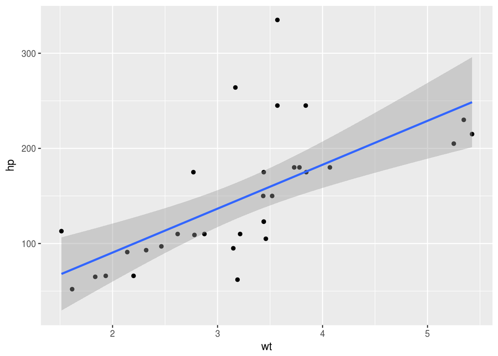

```r
ggplot(mtcars, aes(x = wt, y = hp)) +
  geom_point() +
  geom_smooth(method = "lm")
```

Vemos que existe uma ligeira tendência entre o peso e a potência do carro, o que faz bastante sentido, visto que um carro mais pesado precisa de mais potência para se locomover. Como pode ser visto na correlação a baixo:

```r
cor(mtcars$hp, mtcars$wt)
```

```
## [1] 0.6587479
```

Mas vemos que existem valores um pouco atípicos que atrapalham na correlação entre as variÃ¡veis, com isso, vamos aplicar a função log em ambas variáveis, com intuito de atenuar os valores extremos:

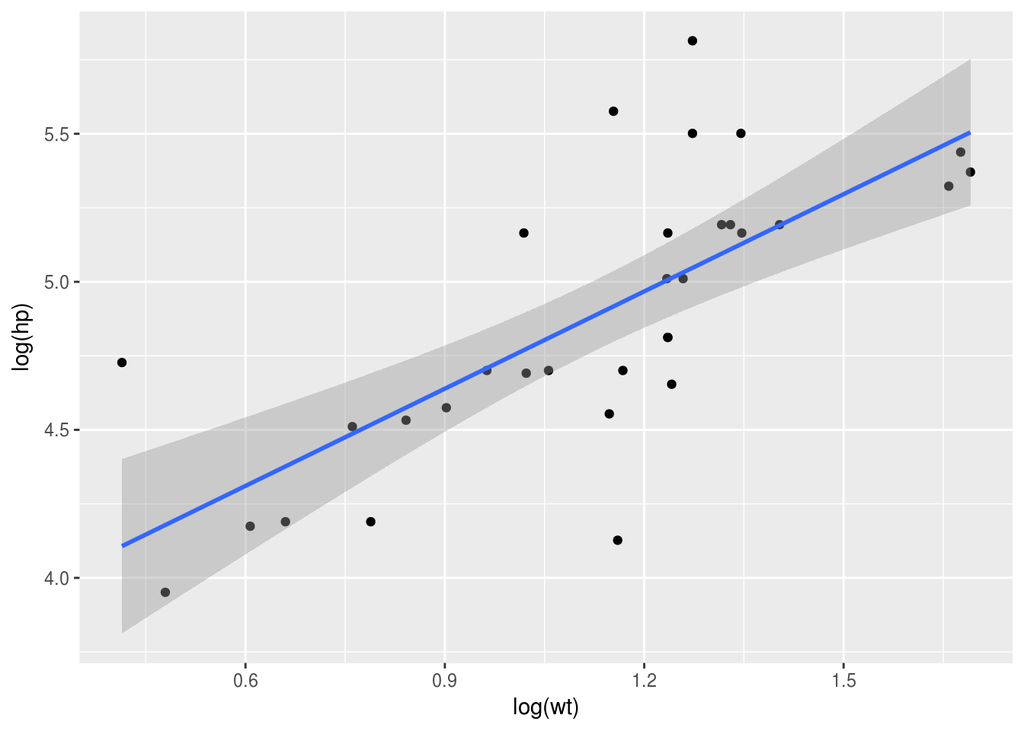

```r
ggplot(mtcars, aes(x = log(wt), y = log(hp))) +
  geom_point() +
  geom_smooth(method = "lm")
```

Com isso, podemos ver que a relação entre as variáveis aumentou, como pode ser visto também pela correlação:

```r
cor(log(wt), log(hp))
```

```
## [1] 0.7314521
```

### Vendo de outra forma

Há duas razões para que transformações como esta sejam aplicadas aos dados: **uma estatística** e **uma proporcional**.

**A primeira**: Supondo que a distribuição da variável em questão possui um viés, ou seja, uma das extremidades elevadas e uma cauda longa, medidas como correlação ou regressão podem ser bastante influenciadas pelo pico da distribuição, outliers, dentre outros. A aplicação da transformação pode reduzir o efeito do viés.

**A segunda**: Alguns conceitos são melhor compreendidos quando tratamos sobre a proporção dos objetos do que sobre a diferença entre eles. Suponha duas empresas, Lindo Olhar e Burguer King, de portes pequeno e muito grande, respectivamente. Lindo Olhar possui um faturamento diário de alguns milhares de reais por dia, enquanto a segunda possui um faturamento de milhões de reais por dia. Se o faturamento da primeira empresa passa de R$ 3.000 para R$ 9.000 (uma diferença de 6 mil reais, razão de 3), é uma grande diferença visto que seu faturamento triplicou. Já se o faturamento da segunda passa de R$ 9.000.000 para R$ 9.006.000 (uma diferença 6 mil reais, razão de pouco mais de 1), [ninguém liga](https://oglobo.globo.com/cultura/kanye-west-da-dez-lojas-do-burger-king-de-presente-para-kim-kardashian-11991528), visto que a diferença foi baixa. Neste caso a transformação logarítmica nos dados de faturamento durante um ano, por exemplo, poderia ser utilizada para comparar o crescimento das empresas de forma justa - podendo ajudar a deixar a relação entre os dados mais clara.

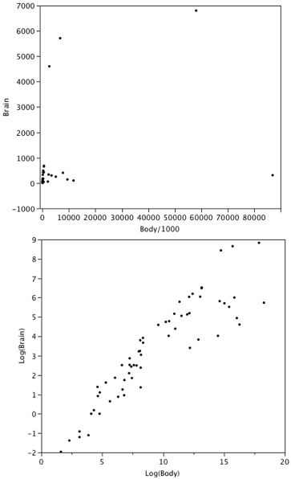

No exemplo acima temos scatterplots do peso do cérebro do animal em função do peso do corpo. Dados brutos no gráfico 1 e com transformação log no gráfico 2. É difícil notar uma relação entre os dados no primeiro gráfico, enquanto no segundo podemos ver a relação entre eles claramente.

O mesmo ocorre para distribuições:

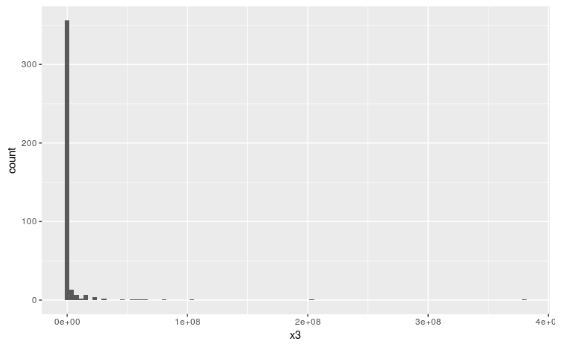

Podemos ver que a distribuições dos dados são bastante enviesadas à direita, mas ao transformarmos para o log na base 10 do valor original, temos uma distribuição bem mais normal:

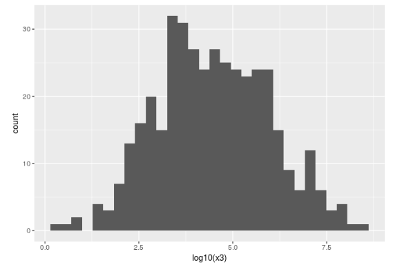

*Referências*

- http://onlinestatbook.com/2/transformations/log.html
- http://fmwww.bc.edu/repec/bocode/t/transint.html
- http://www-ist.massey.ac.nz/dstirlin/CAST/CAST/Hcurvature/curvature_c1.html
- https://blog.majestic.com/case-studies/correlation-data-transformations/